### Predicting Student Performance

The purpose of this exercise is to build a **linear regression** model that will predict final test scores for students.

#### **1. Get our Data**

We will use the [Student Performance Data Set from UC Irvine’s Machine Learning Repository!](https://archive.ics.uci.edu/ml/datasets/Student+Performance)

##### A. Lets read the data and look at the head of our dataset

```r
df <- read.csv('student-mat.csv', sep=';')
head(df)
```

```
##   school sex age address famsize Pstatus Medu Fedu     Mjob     Fjob
## 1     GP   F  18       U     GT3       A    4    4  at_home  teacher
## 2     GP   F  17       U     GT3       T    1    1  at_home    other
## 3     GP   F  15       U     LE3       T    1    1  at_home    other
## 4     GP   F  15       U     GT3       T    4    2   health services
## 5     GP   F  16       U     GT3       T    3    3    other    other
## 6     GP   M  16       U     LE3       T    4    3 services    other
##       reason guardian traveltime studytime failures schoolsup famsup paid
## 1     course   mother          2         2        0       yes     no   no
## 2     course   father          1         2        0        no    yes   no
## 3      other   mother          1         2        3       yes     no  yes
## 4       home   mother          1         3        0        no    yes  yes
## 5       home   father          1         2        0        no    yes  yes
## 6 reputation   mother          1         2        0        no    yes  yes
##   activities nursery higher internet romantic famrel freetime goout Dalc
## 1         no     yes    yes       no       no      4        3     4    1
## 2         no      no    yes      yes       no      5        3     3    1
## 3         no     yes    yes      yes       no      4        3     2    2
## 4        yes     yes    yes      yes      yes      3        2     2    1
## 5         no     yes    yes       no       no      4        3     2    1
## 6        yes     yes    yes      yes       no      5        4     2    1
##   Walc health absences G1 G2 G3
## 1    1      3        6  5  6  6
## 2    1      3        4  5  5  6
## 3    3      3       10  7  8 10
## 4    1      5        2 15 14 15
## 5    2      5        4  6 10 10
## 6    2      5       10 15 15 15
```

##### B. Lets look at the summary of our dataset

```r
summary(df)
```

```
##  school   sex          age       address famsize   Pstatus      Medu
##  GP:349   F:208   Min.   :15.0   R: 88   GT3:281   A: 41   Min.   :0.000
##  MS: 46   M:187   1st Qu.:16.0   U:307   LE3:114   T:354   1st Qu.:2.000
##                   Median :17.0                             Median :3.000
##                   Mean   :16.7                             Mean   :2.749
##                   3rd Qu.:18.0                             3rd Qu.:4.000
##                   Max.   :22.0                             Max.   :4.000
##       Fedu             Mjob           Fjob            reason
##  Min.   :0.000   at_home : 59   at_home : 20   course    :145
##  1st Qu.:2.000   health  : 34   health  : 18   home      :109
##  Median :2.000   other   :141   other   :217   other     : 36
##  Mean   :2.522   services:103   services:111   reputation:105
##  3rd Qu.:3.000   teacher : 58   teacher : 29
##  Max.   :4.000
##    guardian     traveltime      studytime        failures      schoolsup
##  father: 90   Min.   :1.000   Min.   :1.000   Min.   :0.0000   no :344
##  mother:273   1st Qu.:1.000   1st Qu.:1.000   1st Qu.:0.0000   yes: 51
##  other : 32   Median :1.000   Median :2.000   Median :0.0000
##               Mean   :1.448   Mean   :2.035   Mean   :0.3342
##               3rd Qu.:2.000   3rd Qu.:2.000   3rd Qu.:0.0000
##               Max.   :4.000   Max.   :4.000   Max.   :3.0000
##  famsup     paid     activities nursery   higher    internet  romantic
##  no :153   no :214   no :194    no : 81   no : 20   no : 66   no :263
##  yes:242   yes:181   yes:201    yes:314   yes:375   yes:329   yes:132
##
##
##
##
##      famrel         freetime         goout            Dalc
##  Min.   :1.000   Min.   :1.000   Min.   :1.000   Min.   :1.000
##  1st Qu.:4.000   1st Qu.:3.000   1st Qu.:2.000   1st Qu.:1.000
##  Median :4.000   Median :3.000   Median :3.000   Median :1.000
##  Mean   :3.944   Mean   :3.235   Mean   :3.109   Mean   :1.481
##  3rd Qu.:5.000   3rd Qu.:4.000   3rd Qu.:4.000   3rd Qu.:2.000
##  Max.   :5.000   Max.   :5.000   Max.   :5.000   Max.   :5.000
##       Walc           health         absences            G1
##  Min.   :1.000   Min.   :1.000   Min.   : 0.000   Min.   : 3.00
##  1st Qu.:1.000   1st Qu.:3.000   1st Qu.: 0.000   1st Qu.: 8.00
##  Median :2.000   Median :4.000   Median : 4.000   Median :11.00
##  Mean   :2.291   Mean   :3.554   Mean   : 5.709   Mean   :10.91
##  3rd Qu.:3.000   3rd Qu.:5.000   3rd Qu.: 8.000   3rd Qu.:13.00
##  Max.   :5.000   Max.   :5.000   Max.   :75.000   Max.   :19.00
##        G2              G3
##  Min.   : 0.00   Min.   : 0.00
##  1st Qu.: 9.00   1st Qu.: 8.00
##  Median :11.00   Median :11.00
##  Mean   :10.71   Mean   :10.42
##  3rd Qu.:13.00   3rd Qu.:14.00
##  Max.   :19.00   Max.   :20.00
```

#### **2. Clean the Data**

##### A. Check for NA values - Let’s see if we have any NA values

```r
any(is.na(df))
```

```
## [1] FALSE
```

Great, looks like there are no NA values in this dataset.

##### B. Categorical Variables

Let’s check to see which categorical variables have been set as factors and if we need to change the datatype of any of these variables to factors.

```r
str(df)
```

```
## 'data.frame':    395 obs. of  33 variables:
##  $ school    : Factor w/ 2 levels "GP","MS": 1 1 1 1 1 1 1 1 1 1 ...
##  $ sex       : Factor w/ 2 levels "F","M": 1 1 1 1 1 2 2 1 2 2 ...
##  $ age       : int  18 17 15 15 16 16 16 17 15 15 ...
##  $ address   : Factor w/ 2 levels "R","U": 2 2 2 2 2 2 2 2 2 2 ...
##  $ famsize   : Factor w/ 2 levels "GT3","LE3": 1 1 2 1 1 2 2 1 2 1 ...
##  $ Pstatus   : Factor w/ 2 levels "A","T": 1 2 2 2 2 2 2 1 1 2 ...
##  $ Medu      : int  4 1 1 4 3 4 2 4 3 3 ...
##  $ Fedu      : int  4 1 1 2 3 3 2 4 2 4 ...
##  $ Mjob      : Factor w/ 5 levels "at_home","health",..: 1 1 1 2 3 4 3 3 4 3 ...
##  $ Fjob      : Factor w/ 5 levels "at_home","health",..: 5 3 3 4 3 3 3 5 3 3 ...
##  $ reason    : Factor w/ 4 levels "course","home",..: 1 1 3 2 2 4 2 2 2 2 ...
##  $ guardian  : Factor w/ 3 levels "father","mother",..: 2 1 2 2 1 2 2 2 2 2 ...
##  $ traveltime: int  2 1 1 1 1 1 1 2 1 1 ...
##  $ studytime : int  2 2 2 3 2 2 2 2 2 2 ...
```

[output cut: 19 more lines]

We may convert some of the predictors such as ‘Medu’, ‘Fedu’ as factors but we will leave the data as is for now.

#### **3. Exploratory Data Analysis**

We will use ggplot2 to explore our dataset

```r
library(ggplot2)
library(corrplot)
library(corrgram)
library(dplyr)
```

##### A. Correlation and Corrplots

Correlation plots are a great way of exploring data and seeing if there are any interaction terms. Let’s start off by just grabbing the numeric data (we can’t see correlation for categorical data):

```r
# Grab only numeric columns
num.cols <- sapply(df, is.numeric)

# Filter to numeric columns for correlation
cor.data <- cor(df[,num.cols])
```

**Lets look at our correlation data**

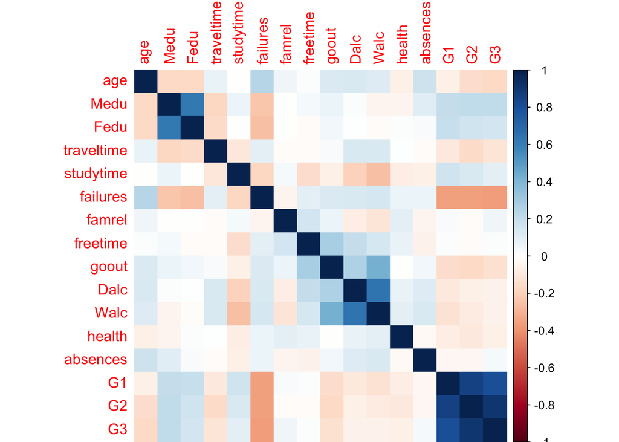

```r
corrplot::corrplot(cor.data, method='color')
```

Cleary we have very high correlation between G1, G2, and G3 which makes sense since those are grades:

- G1 - first period grade (numeric: from 0 to 20)
- G2 - second period grade (numeric: from 0 to 20)
- G3 - final grade (numeric: from 0 to 20, output target)

Meaning good students do well each period, and poor students do poorly each period, etc. Also a high G1,G2, or G3 value has a negative correlation with failure (number of past class failures). Also Mother and Father education levels are correlated, which also makes sense.

**Corrgram -** We can also use the corrgram which allows to just automatically do these type of figures by just **passing in the dataframe directly**.

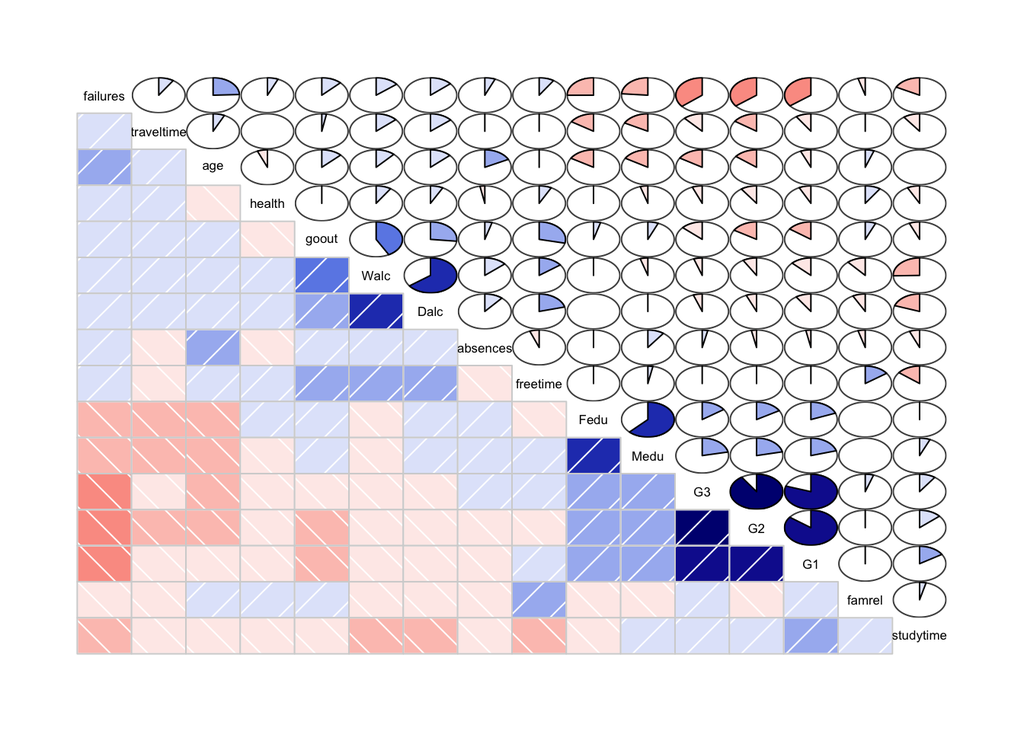

```r
library(corrgram)
corrgram(df, order=TRUE, lower.panel=panel.shade, upper.panel=panel.pie,text.panel=panel.txt)
```

##### B. Histograms

Lets look at a histogram of our response variable G3 that we are going to predict.

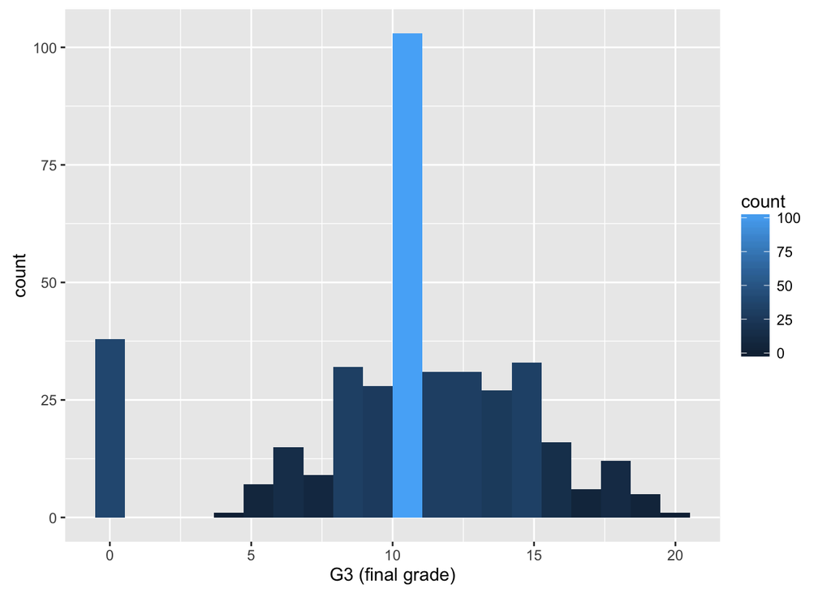

```r
library(ggplot2)
qplot(G3, data=df, geom='histogram', bins=20, fill=..count.., xlab='G3 (final grade)')
```

Looks like quite a few students get a zero. This is a good place to ask questions, like are students missing the test? Also why is the mean occurence so high? Is this test curved?

Let’s continue by building a model

#### **4. Build the model**

##### A. Train and Test Data

We’ll need to split our data into a training set and a testing set in order to test our accuracy.

```r
library(caTools)

# Set the seed
set.seed(101)

# Split the data into test and train sets
sample <- sample.split(df$age, SplitRatio = 0.7)

# Training data
train <- subset(df,sample==TRUE)

# Test data
test <- subset(df,sample==FALSE)
```

##### B. Train our Model

Let’s train out model on our training data, then ask for a summary of that model:

```r
model <- lm(G3~., train)
summary(model)
```

```
##
## Call:
## lm(formula = G3 ~ ., data = train)
##
## Residuals:
##     Min      1Q  Median      3Q     Max
## -7.7681 -0.6423  0.2294  1.0691  4.5942
##
## Coefficients:
##                   Estimate Std. Error t value Pr(>|t|)
## (Intercept)      -1.329568   2.474569  -0.537 0.591574
## schoolMS          0.838581   0.470545   1.782 0.076016 .
## sexM              0.034883   0.275586   0.127 0.899382
## age              -0.214994   0.119579  -1.798 0.073472 .
## addressU          0.067190   0.326035   0.206 0.836905
## famsizeLE3       -0.111068   0.283228  -0.392 0.695302
## PstatusT         -0.153653   0.401679  -0.383 0.702417
## Medu              0.279949   0.171111   1.636 0.103164
## Fedu             -0.221275   0.151103  -1.464 0.144422
## Mjobhealth        0.002065   0.610532   0.003 0.997304
## Mjobother         0.509947   0.403195   1.265 0.207209
## Mjobservices      0.475476   0.435332   1.092 0.275857
## Mjobteacher       0.285345   0.550640   0.518 0.604802
## Fjobhealth        0.433172   0.774191   0.560 0.576343
## Fjobother        -0.296792   0.577217  -0.514 0.607611
## Fjobservices     -0.311595   0.593628  -0.525 0.600148
## Fjobteacher      -0.321205   0.712695  -0.451 0.652628
## reasonhome       -0.431435   0.319907  -1.349 0.178755
## reasonother       0.159612   0.454480   0.351 0.725755
## reasonreputation -0.051845   0.317894  -0.163 0.870589
## guardianmother    0.267462   0.311371   0.859 0.391226
## guardianother    -0.157335   0.554872  -0.284 0.777003
## traveltime        0.274301   0.197865   1.386 0.166968
## studytime        -0.140650   0.155149  -0.907 0.365577
## failures         -0.185333   0.211040  -0.878 0.380739
## schoolsupyes      0.562716   0.379303   1.484 0.139268
## famsupyes         0.369402   0.268848   1.374 0.170745
## paidyes           0.060643   0.270971   0.224 0.823107
## activitiesyes    -0.286006   0.247519  -1.155 0.249063
## nurseryyes       -0.426858   0.315064  -1.355 0.176774
## higheryes         0.503353   0.677346   0.743 0.458148
## internetyes      -0.097405   0.331040  -0.294 0.768834
## romanticyes      -0.243837   0.268414  -0.908 0.364577
## famrel            0.494479   0.136663   3.618 0.000363 ***
## freetime         -0.139869   0.138297  -1.011 0.312879
## goout             0.078871   0.128794   0.612 0.540879
## Dalc             -0.248633   0.178366  -1.394 0.164651
## Walc              0.221434   0.139178   1.591 0.112950
## health            0.027495   0.095100   0.289 0.772748
## absences          0.060830   0.017915   3.396 0.000804 ***
## G1                0.162966   0.076956   2.118 0.035255 *
## G2                0.994677   0.066450  14.969  < 2e-16 ***
## ---
## Signif. codes:  0 '***' 0.001 '**' 0.01 '*' 0.05 '.' 0.1 ' ' 1
##
## Residual standard error: 1.868 on 235 degrees of freedom
## Multiple R-squared:  0.8616, Adjusted R-squared:  0.8374
## F-statistic: 35.68 on 41 and 235 DF,  p-value: < 2.2e-16
```

##### C. Let’s plot the residuals

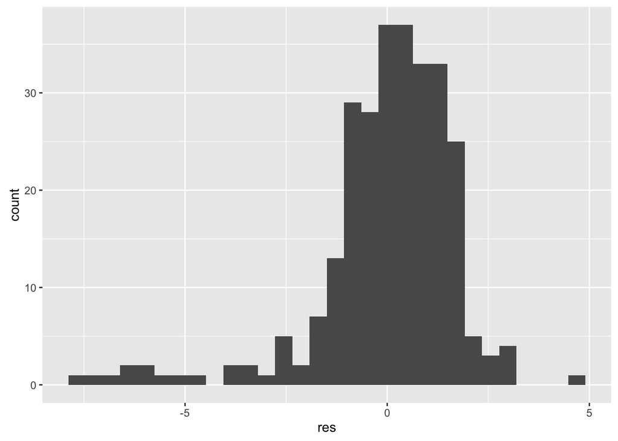

```r
# Grab residuals
res <- residuals(model)

# Convert to data frame for plot
res <- as.data.frame(res)

# Plot residuals
qplot(res, data=res, geom='histogram')
```

Looks like there are some suspicious residual values that have a value less than -5. *Model seems to be predicting that poor performing students will get negative test results*. The lowest possible score however is 0. We can further explore this by just calling plot on our model.

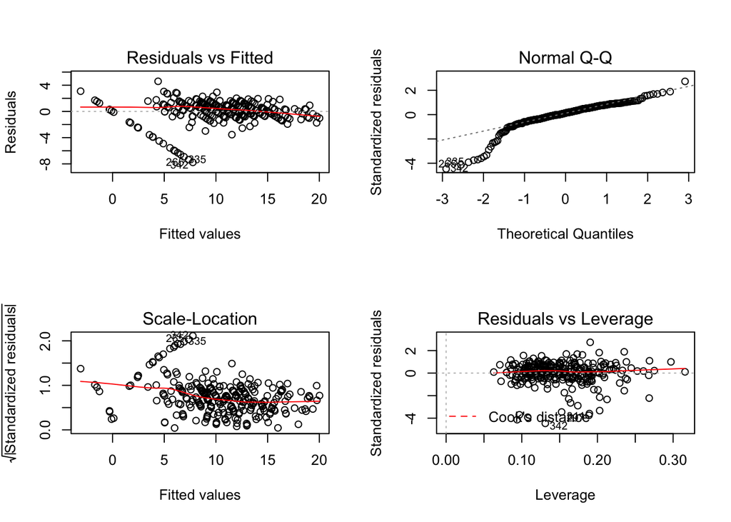

```r
par(mfrow=c(2,2))
plot(model)
```

#### **5. Make Prediction**

##### A. Let’s test our model by predicting on our testing set:

```r
G3.predictions <- predict(model, test)
summary(G3.predictions)
```

```
##    Min. 1st Qu.  Median    Mean 3rd Qu.    Max.
##  -1.832   7.776  10.280  10.240  13.140  20.260
```

Looking at the range, it looks like our model is predicting negative test scores.

##### B. Let’s create a dataset of actual and predicted results to check model performance:

```r
results <- cbind(G3.predictions, test$G3)
colnames(results) <- c('Predicted', 'Real')
results <- as.data.frame(results)
```

##### C. Let’s check the performance of our model:

```r
sse <- sum((results$Predicted - results$Real)^2)
sst <- sum((mean(df$G3) - results$Real)^2)
R2 <- 1-sse/sst
R2
```

```
## [1] 0.7747253
```

Current performance of our model is R2 = 0.774725

##### D. Improve performance

Now let’s take care of negative predictions by creating a simple function to replace them with 0.

```r
# Create function to replace negative values with 0
to_zero <- function(x){
  if(x<0){
    return(0)
  } else {
    return(x)
  }
}

# Apply the function to predicted results
results$Predicted <- sapply(results$Predicted, to_zero)

# Check the range of predicted values
range(results$Predicted)
```

```
## [1]  0.00000 20.25837
```

##### D. Let’s check the performance of our model again:

```r
sse <- sum((results$Predicted - results$Real)^2)
sst <- sum((mean(df$G3) - results$Real)^2)
R2 <- 1-sse/sst
RMSE <- sqrt(mean((results$Real - results$Predicted)^2))
R2
```

```
## [1] 0.7779023
```

```r
RMSE
```

```
## [1] 2.100335
```

##### Conclusion - Performance of our improved model is slightly better with R2 = 0.7779023. It means our model can explain about 78% variance in our test data.